# Tutorial 1

andy south

2016-07-26

This tutorial will be about you doing stuff. I will get you to try things probably before you understand fully what they are. Worry not.

1. It doesn’t matter if you make mistakes.
2. We will come back to some of the concepts later.
3. Questions are encouraged.
4. This should at least give you a start to follow up on later.

The beauty (& sometimes otherwise) of R is that there are usually multiple ways of doing the same thing. Here I will show one way, this will help you learn some concepts but you may well find that alternatives are better suited to your needs.

### Install the R package for the course

```r
#first install devtools to enable install from GitHub
install.packages("devtools")
library(devtools)
install_github('AndySouth/rmapteach')
```

Load the R package for the course

```r
library("rmapteach")
```

### A) point plots with ggplot2 first go

```r
# load the package
library("ggplot2")

# load some data on mammal sleep patterns from the package
data(msleep)

# to show the 'str'ucture of the data
str(msleep)
```

```
## Classes 'tbl_df', 'tbl' and 'data.frame':    83 obs. of  11 variables:
##  $ name        : chr  "Cheetah" "Owl monkey" "Mountain beaver" "Greater short-tailed shrew" ...
##  $ genus       : chr  "Acinonyx" "Aotus" "Aplodontia" "Blarina" ...
##  $ vore        : chr  "carni" "omni" "herbi" "omni" ...
##  $ order       : chr  "Carnivora" "Primates" "Rodentia" "Soricomorpha" ...
##  $ conservation: chr  "lc" NA "nt" "lc" ...
##  $ sleep_total : num  12.1 17 14.4 14.9 4 14.4 8.7 7 10.1 3 ...
##  $ sleep_rem   : num  NA 1.8 2.4 2.3 0.7 2.2 1.4 NA 2.9 NA ...
##  $ sleep_cycle : num  NA NA NA 0.133 0.667 ...
##  $ awake       : num  11.9 7 9.6 9.1 20 9.6 15.3 17 13.9 21 ...
##  $ brainwt     : num  NA 0.0155 NA 0.00029 0.423 NA NA NA 0.07 0.0982 ...
##  $ bodywt      : num  50 0.48 1.35 0.019 600 ...
```

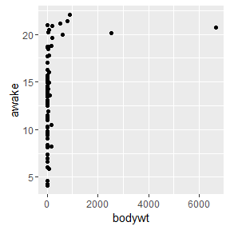

```r
# first plot
ggplot(data = msleep, aes(x = bodywt, y = awake)) +
    geom_point()
```

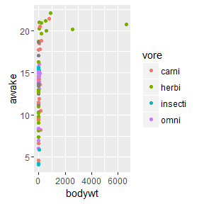

```r
# aes (for aesthetic) sets up links between the data and aspects of the plot
# + adds layers to the plot, in this case points
# bodywt and awake are columns within the data

# add an extra column to the aes
ggplot(data = msleep, aes(x = bodywt, y = awake, col = vore)) +
    geom_point()
```

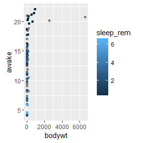

```r
# if you change col= to a column that is numeric it changes the legend
ggplot(data = msleep, aes(x = bodywt, y = awake, col = sleep_rem)) +
    geom_point()
```

### A1) Exercise

Have a quick look at the online ggplot2 documentation here : http://docs.ggplot2.org/current/

Try modifying a point plot with the msleep data.

### point plots, modifying axes, label points, divide into subplots

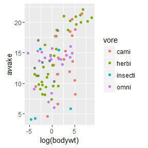

```r
# we can log bodywt to space the points out more
ggplot(data = msleep, aes(x = log(bodywt), y = awake, col = vore)) +
    geom_point()
```

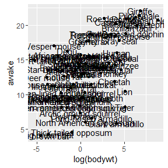

```r
# label the points for data exploration
ggplot(data = msleep, aes(x = log(bodywt), y = awake, label = name)) +
    geom_point() +
    geom_text()
```

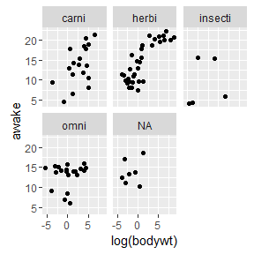

```r
# divide into subplots using facet_wrap()
ggplot(data = msleep, aes(x = log(bodywt), y = awake, label = name)) +
    geom_point() +
    facet_wrap(~vore)
```

### 1 maps

Install and load the tmap package

```r
install.packages("tmap")
```

```r
library("tmap")
```

### 1.1 Getting started with polygon maps

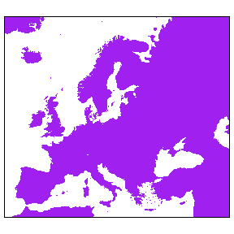

```r
# load data from tmap
data(Europe)
# set shapes and fill them
tm_shape(Europe) +
  tm_fill("purple")
```

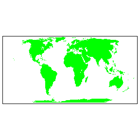

```r
# load data from tmap
data(World)
# set shapes and fill them
tm_shape(World) +
  tm_fill("green")
```

```r
# check what data are associated with a map using 'str(*@data)', str stands for structure
str(World@data)
```

```
## 'data.frame':    177 obs. of  15 variables:
##  $ iso_a3      : Factor w/ 235 levels "ABW","AFG","AGO",..: 2 3 6 8 9 10 12 13 15 16 ...
##  $ name        : Factor w/ 241 levels "Afghanistan",..: 1 7 3 228 11 12 9 76 15 16 ...
##  $ sovereignt  : Factor w/ 200 levels "Afghanistan",..: 1 5 2 187 8 9 6 60 10 11 ...
##  $ continent   : Factor w/ 8 levels "Africa","Antarctica",..: 3 1 4 3 8 3 2 7 6 4 ...
##  $ subregion   : Factor w/ 24 levels "Antarctica","Australia and New Zealand",..: 20 11 21 23 18 23 1 16 2 24 ...
##  $ area        : num  652860 1246700 27400 83600 2736690 ...
##  $ pop_est     : num  28400000 12799293 3639453 4798491 40913584 ...
##  $ pop_est_dens: num  43.5 10.3 132.8 57.4 15 ...
##  $ gdp_md_est  : num  22270 110300 21810 184300 573900 ...
##  $ gdp_cap_est : num  784 8618 5993 38408 14027 ...
##  $ economy     : Factor w/ 7 levels "1. Developed region: G7",..: 7 7 6 6 5 6 6 6 2 2 ...
##  $ income_grp  : Ord.factor w/ 5 levels "1. High income: OECD"<..: 5 3 4 2 3 4 2 2 1 1 ...
##  $ life_exp    : num  48.7 51.1 76.9 76.5 75.9 74.2 NA NA 81.9 80.9 ...
##  $ well_being  : num  4.76 4.21 5.27 7.2 6.44 ...
##  $ HPI         : num  36.8 33.2 54.1 31.8 54.1 ...
```

```r
str(Europe@data)
```

```
## 'data.frame':    68 obs. of  16 variables:
##  $ iso_a3      : Factor w/ 67 levels "ALA","ALB","AND",..: 2 1 3 4 5 6 7 8 9 10 ...
##  $ name        : Factor w/ 68 levels "Aland","Albania",..: 2 1 4 5 6 7 9 11 10 8 ...
##  $ sovereignt  : Factor w/ 61 levels "Albania","Algeria",..: 1 16 3 4 5 6 8 10 9 7 ...
##  $ continent   : Factor w/ 4 levels "Africa","Asia",..: 3 3 3 2 3 2 3 3 3 3 ...
##  $ part        : Factor w/ 4 levels "Northern Europe",..: 3 1 3 NA 2 NA 2 4 3 4 ...
##  $ EU_Schengen : Factor w/ 4 levels "EU Schengen",..: NA NA NA NA 1 NA 1 2 NA NA ...
##  $ area        : num  27400 674 470 NA 82409 ...
##  $ pop_est     : num  3639453 27153 83888 NA 8210281 ...
##  $ pop_est_dens: num  132.8 40.3 178.5 NA 99.6 ...
##  $ gdp_md_est  : num  21810 1563 3660 NA 329500 ...
##  $ gdp_cap_est : num  5993 57563 43630 NA 40133 ...
##  $ economy     : Factor w/ 7 levels "1. Developed region: G7",..: 6 2 2 NA 2 NA 2 2 6 6 ...
##  $ income_grp  : Ord.factor w/ 5 levels "1. High income: OECD"<..: 4 1 2 NA 1 NA 1 3 3 3 ...
##  $ life_exp    : num  76.9 NA NA NA 80.9 NA 80 73.4 75.7 70.3 ...
##  $ well_being  : num  5.27 NA NA NA 7.35 ...
##  $ HPI         : num  54.1 NA NA NA 47.1 ...
```

```r
# note that str(Europe) shows all the geometry information too and is not very useful here

# check the contents of Factor variables using 'levels'
levels(Europe$part)
```

```
## [1] "Northern Europe" "Western Europe"  "Southern Europe" "Eastern Europe"
```

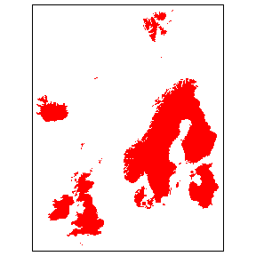

```r
# levels(Europe@data$part) gives the same output, you don't always need the @data to get at the variables

# plot a subset of the map using '[which(*),]'
tm_shape(Europe[which(Europe$part=='Northern Europe'),]) +
  tm_fill("red")
```

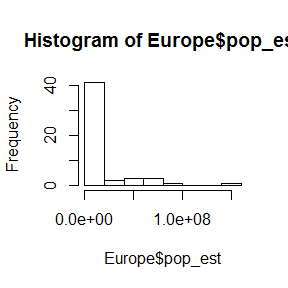

```r
# check the contents of numeric variables using 'hist'
hist(Europe$pop_est)
```

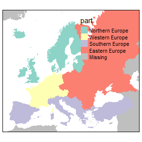

```r
# fill polygons on a map based on data variables
# factor
tm_shape(Europe) +
  tm_fill("part")
```

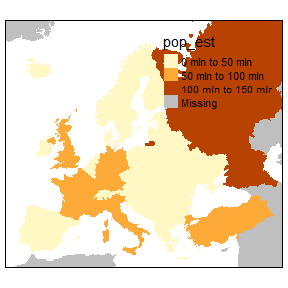

```r
# numeric
tm_shape(Europe) +
  tm_fill("pop_est")
```

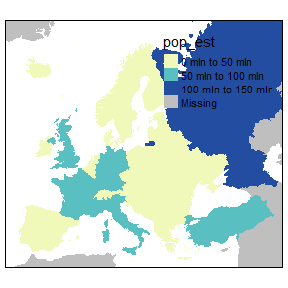

```r
# the previous commands used default colours, you can modify these with 'palette'
tm_shape(Europe) +
  tm_fill("pop_est", palette = "YlGnBu")
```

[figure not shown]

```r
# to see available palettes
RColorBrewer::display.brewer.all()
```

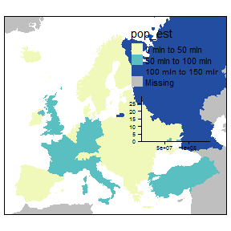

```r
# to add a histogram to the legend
tm_shape(Europe) +
  tm_fill("pop_est", palette = "YlGnBu", legend.hist = TRUE)
```

```r
# maps are stored as a SpatialPolygonsDataFrame from the package sp
# you can find this out by typing
class(Europe)
```

```
## [1] "SpatialPolygonsDataFrame"
## attr(,"package")
## [1] "sp"
```

### 1.2 Exercise : can you plot different areas, different variables, different colours …

```r
# to see help use '?'
?tm_fill

# syntax is like ggplot2 (e.g. + to add layers)

# start with one of the code examples above and change something ...
```

### 2.1 Getting started with point maps

```r
# load some tmap point data for metropolitan areas
data(metro)
# ?metro gives information about the data
# this is also an sp object with associated variables
class(metro)
```

```
## [1] "SpatialPointsDataFrame"
## attr(,"package")
## [1] "sp"
```

```r
str(metro@data)
```

```
## 'data.frame':    436 obs. of  12 variables:
##  $ name     : chr  "Kabul" "Algiers" "Luanda" "Buenos Aires" ...
##  $ name_long: chr  "Kabul" "El Djazair  (Algiers)" "Luanda" "Buenos Aires" ...
##  $ iso_a3   : chr  "AFG" "DZA" "AGO" "ARG" ...
##  $ pop1950  : num  170784 516450 138413 5097612 429249 ...
##  $ pop1960  : num  285352 871636 219427 6597634 605309 ...
##  $ pop1970  : num  471891 1281127 459225 8104621 809794 ...
##  $ pop1980  : num  977824 1621442 771349 9422362 1009521 ...
##  $ pop1990  : num  1549320 1797068 1390240 10513284 1200168 ...
##  $ pop2000  : num  2401109 2140577 2591388 12406780 1347561 ...
##  $ pop2010  : num  3722320 2432023 4508434 14245871 1459268 ...
##  $ pop2020  : num  5721697 2835218 6836849 15894307 1562509 ...
##  $ pop2030  : num  8279607 3404575 10428756 16956491 1718192 ...
```

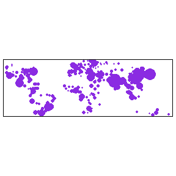

```r
# plot points as bubbles
tm_shape(metro) +
    tm_bubbles("pop2010", legend.size.show = FALSE)
```

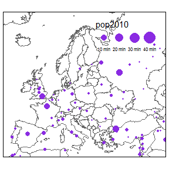

```r
# plot points on top of a European map
tm_shape(Europe) +
  tm_borders() +
tm_shape(metro) +
  tm_bubbles("pop2010")
```

### 2.2 Exercise - can you cahnge one of the point maps ?

### 3.1 Getting started with raster maps

```r
# load some data from tmap
data(land)

class(land)
```

```
## [1] "SpatialGridDataFrame"
## attr(,"package")
## [1] "sp"
```

```r
str(land@data)
```

```
## 'data.frame':    583200 obs. of  4 variables:
##  $ cover    : Factor w/ 20 levels "Broadleaf Evergreen Forest",..: 20 20 20 20 20 20 20 20 20 20 ...
##  $ cover_cls: Factor w/ 8 levels "Forest","Other natural vegetation",..: 8 8 8 8 8 8 8 8 8 8 ...
##  $ trees    : int  NA NA NA NA NA NA NA NA NA NA ...
##  $ elevation: int  NA NA NA NA NA NA NA NA NA NA ...
```

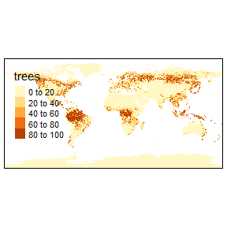

```r
tm_shape(land) +
    tm_raster("trees", breaks=seq(0, 100, by=20) )
```

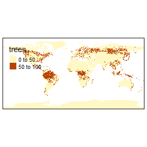

```r
tm_shape(land) +
    tm_raster("trees", breaks=seq(0, 100, by=50) )
```

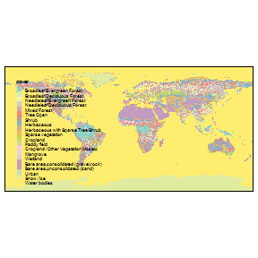

```r
# categorical land cover
tm_shape(land) +
    tm_raster("cover")
```

[figure not shown]

```r
# using faceting

# facet by cover to get one map for each cover type
tm_shape(land) +
    tm_raster("cover", legend.show = FALSE) +
    tm_facets("cover", free.coords=TRUE, drop.units=TRUE)
```

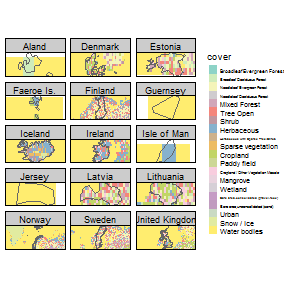

```r
# facet by country to get one cover map per country
tm_shape(land) +
    tm_raster("cover") + # , legend.show = FALSE)
tm_shape(Europe[which(Europe$part=="Northern Europe"),]) +
    tm_borders() +
    tm_facets("name", free.coords = TRUE)
```

### 4 Using your own data

You can use both your own geometry and/or attribute data in tmap and other mapping options.

```r
# create a very simple data frame as an example
dF <- data.frame( country=c("Spain", "United Kingdom"),
                  weather=c("hot", "cold") )

# tmap can join this onto a map (other options are available too)
Eu_and_dat <- append_data(Europe, dF, key.shp="name", key.data="country")
```

```
## Under coverage. No data for 66 out of 68 polygons: Albania, Aland, Andorra, Armenia, Austria, ...
```

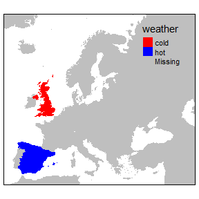

```r
tm_shape(Eu_and_dat) +
  tm_fill("weather", palette=c("red","blue"))
```

```r
# Can you plot some other data by country ?
# remember the country names in the map are in Europe$name
# TODO me to add getting data from another package
```

### 6 Putting it all together or experiment with other options

```r
# to list datasets in the tmap package
data(package="tmap")
```

### 7 Going further

```r
# other useful packages, resources

# raster package
library(raster)

# rmapshaper for simplifying polygon boundaries
library(rmapshaper)
```